# Lab 4: Categorical and Continuous Predictors

ED 214B

Winter 2024

## Introduction

```r
library(readxl) # import excel
library(car) # levene's test
library(psych) # describe
library(tidyverse) # ggplot
```

### Research Question

Does the place in which a person grows up impact their academic achievement?

### Testable Hypotheses

1. Is the type of location (urban/rural) a student grows up in related to their standardized math test scores?
2. Is a student’s family income and the type of location (urban/rural) the student grows up in related to their standardized math test scores?
- Independent variables
  - Type of location (Nominal)
    - Variable: School_Locale
    - 0: Urban
    - 1: Rural
  - Income (Continuous)
    - Variable: Income
- Dependent variable
  - Math score (Continuous)
    - Variable: X1MTSCOR

### Read in the data

```r
Week3 <- read_excel("Week3_9999.xlsx")
View(Week3)
```

## T-tests

- Used when we have a categorical predictor and a continuous outcome

**Review from last quarter**

Levene’s test is the test for equality of variances (homogeneity of variance). It assumes that the variances of the two groups are equal. If it is significant, it is violated. When it is violated, we add `var.equal=FALSE` because it is a t-test that is corrected for this violation (and therefore does not assume equal variances across the two groups).

#### The default in R is to assume that variances aren’t equal

```r
#Recode missing
Week3$X1MTSCOR[Week3$X1MTSCOR==9999] <- NA
Week3$School_Locale[Week3$School_Locale==9999] <- NA
```

```r
t.test(X1MTSCOR~School_Locale,data=Week3)
```

```
##
##  Welch Two Sample t-test
##
## data:  X1MTSCOR by School_Locale
## t = 12.367, df = 18280, p-value < 2.2e-16
## alternative hypothesis: true difference in means between group 0 and group 1 is not equal to 0
## 95 percent confidence interval:
##  1.480587 2.038298
## sample estimates:
## mean in group 0 mean in group 1
##        52.19870        50.43926
```

```r
#Default is var.equal=FALSE, so we don't need to add it
```

### To see the t-test results for when variances are assumed to be equal, add `var.equal=TRUE`

```r
t.test(Week3$X1MTSCOR~Week3$School_Locale, var.equal=TRUE)
```

```
##
##  Two Sample t-test
##
## data:  Week3$X1MTSCOR by Week3$School_Locale
## t = 12.292, df = 19914, p-value < 2.2e-16
## alternative hypothesis: true difference in means between group 0 and group 1 is not equal to 0
## 95 percent confidence interval:
##  1.478880 2.040006
## sample estimates:
## mean in group 0 mean in group 1
##        52.19870        50.43926
```

### Run Levene’s test to figure out which one to use

```r
#First, we need to tell R that School_Locale is a factor instead of numeric
Week3$School_Locale<-as.factor(Week3$School_Locale)

car::leveneTest(X1MTSCOR~School_Locale, data=Week3)
```

```
## Levene's Test for Homogeneity of Variance (center = median)
##          Df F value    Pr(>F)
## group     1   22.15 2.539e-06 ***
##       19914
## ---
## Signif. codes:  0 '***' 0.001 '**' 0.01 '*' 0.05 '.' 0.1 ' ' 1
```

### Check Variable Type

```r
class(Week3$School_Locale)
```

```
## [1] "factor"
```

### Standard Deviation for Each Group

```r
describeBy(Week3$X1MTSCOR,Week3$School_Locale)
```

```
##
##  Descriptive statistics by group
## group: 0
##    vars     n mean    sd median trimmed  mad   min   max range skew kurtosis
## X1    1 11606 52.2 10.11  51.99   52.36 9.96 24.02 82.19 58.17 -0.1    -0.15
##      se
## X1 0.09
## ------------------------------------------------------------
## group: 1
##    vars    n  mean   sd median trimmed mad   min   max range  skew kurtosis
## X1    1 8310 50.44 9.75  50.43   50.58 9.2 24.32 82.19 57.87 -0.07    -0.05
##      se
## X1 0.11
```

### Interpretation

An independent samples t-test was conducted to compare **math scores** with the **type of location** that a student grows up in. There was a statistically significant difference in math scores for students who grew up in an urban area (M = 52.20, SD = 10.11) and students who grew up in a rural area (M = 50.44, SD = 9.75); t = 12.367, p < .001. We are 95% confident that the average mean difference in math scores between students who live in urban and rural areas falls between 1.48 and 2.04 points on the standardized math test.

## Simple linear regression with one categorical predictor

Let’s replicate this test using a regression model!

We’re running the same model:

$$\hat{y}={\beta_0}+{\beta_1}*{d_i}$$
$$\hat{X1MTSCOR}={\beta_0}+{\beta_1}*{SchoolLocale_i}$$

```r
slr <- lm(X1MTSCOR~School_Locale,data=Week3)
summary(slr)
```

```
##
## Call:
## lm(formula = X1MTSCOR ~ School_Locale, data = Week3)
##
## Residuals:
##     Min      1Q  Median      3Q     Max
## -28.181  -6.032  -0.107   6.952  31.748
##
## Coefficients:
##                Estimate Std. Error t value Pr(>|t|)
## (Intercept)    52.19870    0.09246  564.55   <2e-16 ***
## School_Locale1 -1.75944    0.14314  -12.29   <2e-16 ***
## ---
## Signif. codes:  0 '***' 0.001 '**' 0.01 '*' 0.05 '.' 0.1 ' ' 1
##
## Residual standard error: 9.961 on 19914 degrees of freedom
##   (3587 observations deleted due to missingness)
## Multiple R-squared:  0.00753,    Adjusted R-squared:  0.00748
## F-statistic: 151.1 on 1 and 19914 DF,  p-value: < 2.2e-16
```

The *t-statistic* tells us the likelihood that the regression coefficient found in our model is different from zero. The closer the T value is to 0, the less likely there is a significant difference. You must look at the p-value next to it to get the full picture.

### Confidence Intervals

```r
confint(slr)
```

```
##                    2.5 %   97.5 %
## (Intercept)    52.017470 52.37993
## School_Locale1 -2.040006 -1.47888
```

### ANOVA

```r
anova(slr)
```

```
## Analysis of Variance Table
##
## Response: X1MTSCOR
##                  Df  Sum Sq Mean Sq F value    Pr(>F)
## School_Locale     1   14991 14991.0  151.09 < 2.2e-16 ***
## Residuals     19914 1975836    99.2
## ---
## Signif. codes:  0 '***' 0.001 '**' 0.01 '*' 0.05 '.' 0.1 ' ' 1
```

Let’s plug the values into the equation:

$$\hat{X1MTSCOR}=52.20-1.76*{SchoolLocale_i}$$

Where School_locale can take on a value of 0 (Urban) or 1 (Rural).

When School_locale = 0, we only have the intercept. When School_locale = 1, the slope is “activated”. Therefore, the slope is mean difference between the two groups! *Same as the t-test above!*

$$\hat{X1MTSCOR}=52.20-(1.76*0)=52.20$$

$$\hat{X1MTSCOR}=52.20-(1.76*1)=50.44$$

Note that the confidence intervals are virtually the same between the two (the regression equation doesn’t correct for the violation of homogeneity of variance, but it doesn’t change our interpretation with a sample size this large, anyway).

### Interpretation

Using a regression model, we found that the **type of location** that a student grows up in was a significant predictor of their **math scores** ($p$<.001, ${R^2}$=.008). On average, students in rural areas had lower scores than students in urban areas ($\beta$=-1.76, $p$ < .001). We are 95% confident that the true difference between students in urban and rural scores falls between -2.04 and -1.48 points on a standardized math test.

The reason the confidence interval is negative here and not in the t-test is that if you look at the regression model, it is because it chose rural (1) since it activated the slope! So, because rural’s mean is lower than urban’s mean, it is negative. Hope that makes sense!

## Multiple Linear Regression

Finally, let’s answer the second part of our research question: what happens when we control for family income?

We’re running a new model:

$$\hat{y}={\beta_0}+{\beta_1}*{d_i}+{\beta_2}*{X_i}$$

$$\hat{X1MTSCOR}={\beta_0}+{\beta_1}*{SchoolLocale_i}+{\beta_2}*{Income_i}$$

```r
#First, recode missing
Week3$Income[Week3$Income==9999] <- NA

mlr <- lm(X1MTSCOR~School_Locale+Income,data=Week3)
summary(mlr)
```

```
##
## Call:
## lm(formula = X1MTSCOR ~ School_Locale + Income, data = Week3)
##
## Residuals:
##     Min      1Q  Median      3Q     Max
## -32.684  -5.760   0.142   6.131  33.267
##
## Coefficients:
##                  Estimate Std. Error t value Pr(>|t|)
## (Intercept)     1.300e+01  5.920e-01  21.953  < 2e-16 ***
## School_Locale1 -6.913e-01  1.303e-01  -5.305 1.14e-07 ***
## Income          5.480e-04  8.192e-06  66.896  < 2e-16 ***
## ---
## Signif. codes:  0 '***' 0.001 '**' 0.01 '*' 0.05 '.' 0.1 ' ' 1
##
## Residual standard error: 9.001 on 19913 degrees of freedom
##   (3587 observations deleted due to missingness)
## Multiple R-squared:  0.1896, Adjusted R-squared:  0.1896
## F-statistic:  2330 on 2 and 19913 DF,  p-value: < 2.2e-16
```

### Confidence Intervals

```r
confint(mlr)
```

```
##                        2.5 %        97.5 %
## (Intercept)    11.8349546439 14.1555296203
## School_Locale1 -0.9467946391 -0.4358970654
## Income          0.0005319398  0.0005640527
```

### ANOVA

- $H_0$: All group means are equal.
- $H_a$: At least one group mean is different from the rest.

```r
anova(mlr)
```

```
## Analysis of Variance Table
##
## Response: X1MTSCOR
##                  Df  Sum Sq Mean Sq F value    Pr(>F)
## School_Locale     1   14991   14991  185.04 < 2.2e-16 ***
## Income            1  362558  362558 4475.13 < 2.2e-16 ***
## Residuals     19913 1613277      81
## ---
## Signif. codes:  0 '***' 0.001 '**' 0.01 '*' 0.05 '.' 0.1 ' ' 1
```

The F-statistic determines the ratio of explained variance to unexplained variance. A greater F-statistic means there is more evidence that there is a difference between the group means.

### Interpretation

Using a regression model, we found that the **type of location** that a student grows up in and their family’s **income** were significant predictors of their **math scores** ($p$<.001, ${R^2}$=.19). Controlling for family income, students in rural areas had (on average) lower scores than students in urban areas ($\beta$=-.69, $p$ < .001). Controlling for **type of location**, a one-unit increase in **income** corresponds to a .0005480 unit increase in **math scores** ($\beta$=.0005480, $p$ < .001).

*Note*: The effect of income on math scores seems non-existent, but this is just because the scale of the income variable is much larger than the scale of the math score variable. If we run descriptives, we see:

```r
describe(Week3$Income)
```

```
##    vars     n     mean      sd median trimmed     mad   min   max range skew
## X1    1 21444 70540.94 7803.04  69891 70250.8 7857.78 50698 98807 48109 0.37
##    kurtosis    se
## X1    -0.09 53.29
```

```r
describe(Week3$X1MTSCOR)
```

```
##    vars     n  mean    sd median trimmed  mad   min   max range  skew kurtosis
## X1    1 21444 51.11 10.08  50.97   51.24 9.83 24.02 82.19 58.17 -0.06    -0.13
##      se
## X1 0.07
```

We can make the equation easier to understand by simply multiplying Income by 10,000.

```r
.0005480*10000
```

```
## [1] 5.48
```

Thus, we can say: “Controlling for **type of location**, a $10,000 increase in **income** is associated with an increase of 5.48 points on math test scores ($\beta$=.0005480, $p$ < .001).”

### Plotting the Regression Lines from the MLR

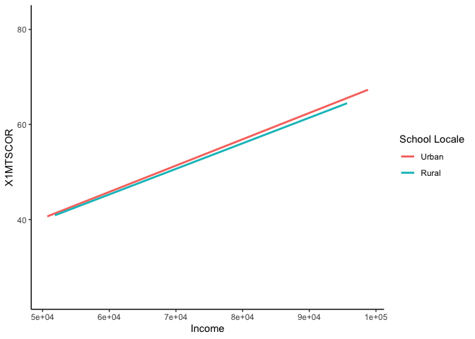

```r
Week3 %>%
  na.omit() %>%
  ggplot(aes(y=X1MTSCOR,x=Income))+
  geom_point(alpha=0)+
  geom_smooth(aes(colour=School_Locale),method="lm",fill=NA)+
  theme_classic()+
  scale_colour_discrete(name="School Locale",breaks=c("0","1"),labels=c("Urban","Rural"))
```

Let’s figure out what all of this means…

- `na.omit` = remove the missing values from the plot
- `ggplot(aes(y=X1MTSCOR,x=Income))` = set the aesthetics (x and y) for the main graph
- `geom_point()` = tell ggplot that we want a scatterplot
- `alpha=0` = set the transparency to 100% (aka, hide the data)
- `geom_smooth(method="lm")` = add a regression line to the graph
- `aes(colour=School_Locale)` = set the aesthetics of the regression lines so that there is a different line for each group, each with a different color
- `fill=NA` = hide the default standard error lines
- `theme_classic()` = make the graph simple with a white background and no gridlines
- `scale_colour_discrete` = re-label legend
  - for more info, see: http://www.cookbook-r.com/Graphs/Legends_(ggplot2)/